# Coursera JHU Datascience: Reproducible Research: Peer Assessment 1

Balaji Iyengar

## Loading and preprocessing the data

```r
entity_df <- read.csv("activity.csv")
```

Print sample observations

```r
myprint_sample <- function(df) {
    print(head(df))

    # print 6 sample obs
    print(df[sort(sample(1:dim(df)[1], 6)),])

    print(tail(df))
}

myprint_sample(entity_df)
```

```
##   steps       date interval
## 1    NA 2012-10-01        0
## 2    NA 2012-10-01        5
## 3    NA 2012-10-01       10
## 4    NA 2012-10-01       15
## 5    NA 2012-10-01       20
## 6    NA 2012-10-01       25
##       steps       date interval
## 2361      0 2012-10-09      440
## 4763      0 2012-10-17     1250
## 4856      0 2012-10-17     2035
## 5026      0 2012-10-18     1045
## 5074      0 2012-10-18     1445
## 16432     0 2012-11-27      115
##       steps       date interval
## 17563    NA 2012-11-30     2330
## 17564    NA 2012-11-30     2335
## 17565    NA 2012-11-30     2340
## 17566    NA 2012-11-30     2345
## 17567    NA 2012-11-30     2350
## 17568    NA 2012-11-30     2355
```

## What is mean total number of steps taken per day?

#### Make a histogram of the total number of steps taken each day

Sum steps by date

```r
myaggregate_numorlgcl <- function (df, by_names, func) {

    # Keep only numeric or logical columns
    dfcols_df <- data.frame(type=sapply(df, class))
    keep_cols <- rownames(dfcols_df)[dfcols_df[, "type"] %in%
                                     c("integer", "numeric", "logical")]
    # Drop cols in by_names
    keep_cols <- setdiff(keep_cols, by_names)

    # Build df with only numeric/logical & by cols
    subset_df <- cbind(df[, keep_cols, drop=FALSE], df[, by_names, drop=FALSE])
    names(subset_df) <- c(keep_cols, by_names)

    # Drop obs with NAs
    num_complete_cases <- sum(complete.cases(subset_df))
    if (num_complete_cases < dim(df)[1]) {
        num_excl_cases <- dim(df)[1] - num_complete_cases
        warning (sprintf("excluding %s (%0.1f pct) obs with NA",
                         prettyNum(num_excl_cases, big.mark=","),
                         num_excl_cases * 100.0 / dim(df)[1]))
        subset_df <- subset_df[complete.cases(subset_df), , drop=FALSE]
    }

    by_lst <- sapply(by_names, function(byvar) list(subset_df[, byvar]))
    agg_df <- aggregate(subset_df[, keep_cols], by_lst, func)

    # Add a suffix of the function name to the aggregated columns
    func_names_dct <- list(mean=mean, sum=sum)
    if (c(func) %in% func_names_dct) {
        name_suffix <- names(func_names_dct)[match(c(func), func_names_dct)]
        new_col_names <- sapply(keep_cols, function(name) paste(name,
                                                                name_suffix,
                                                                sep="_"))
        names(agg_df) <- c(by_names, new_col_names)
    } else warning("column names renaming unsupported for unknown func",
                   str(func))

    return(agg_df)
}

entity_agg_date_df <- myaggregate_numorlgcl(subset(entity_df,
                                                   select=-c(interval)),
                                            "date", sum)
```

Create weekday / weekend feature

```r
mycreate_date2daytype <- function (df, date_col_name) {
    new_df <- df

    day_col_name <- paste(date_col_name, "day", sep="_")
    new_df[, day_col_name] <- weekdays(as.Date(df[, date_col_name]))

    daytype_col_name <- paste(date_col_name, "dytyp", sep="_")
    new_df[, daytype_col_name] <- ifelse((new_df[, day_col_name] == "Saturday") |
                                         (new_df[, day_col_name] == "Sunday"),
                                         "weekend", "weekday")
    return(new_df)
}

entity_agg_date_df <- mycreate_date2daytype(entity_agg_date_df, "date")
```

Plot histogram of steps by date & fill with day type

```
## stat_bin: binwidth defaulted to range/30. Use 'binwidth = x' to adjust this.
```

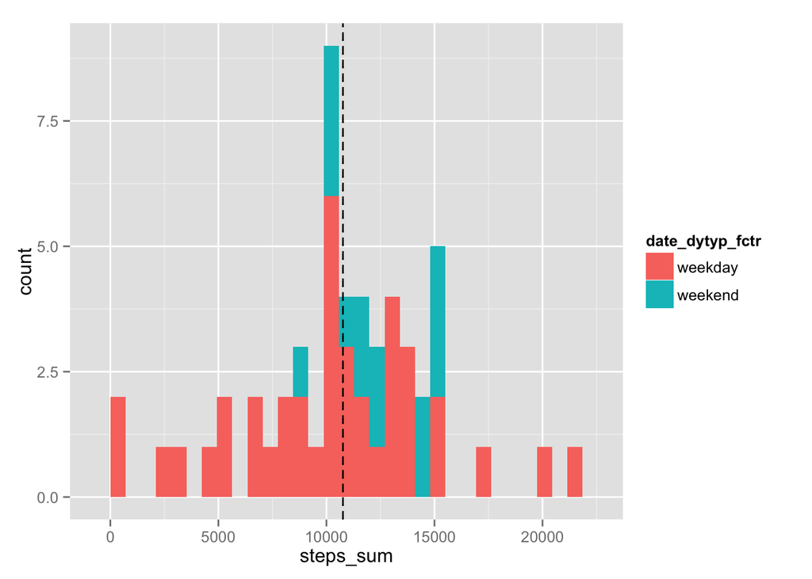

```r
myplot_histogram <- function(df, hst_col_name, fill_col_name=NULL) {
    require(ggplot2)

    if (is.null(fill_col_name)) {
        # Fill with raw counts
        g <- ggplot(df, aes_string(x=hst_col_name))
        g + geom_histogram(aes(fill=..count..)) +
            scale_fill_gradient("Count", low="red", high="blue")
    }
    else {
        # If fill variable has 5 or less unique values use raw data
        if (length(unique(df[, fill_col_name])) <= 5) {

            # if fill variable is a factor use raw data
            if (class(df[, fill_col_name]) == "factor") {
                g <- ggplot(df, aes_string(x=hst_col_name, fill=fill_col_name))
            } else {
            # else create a factor of the fill variable
                fill_col_fctr_name <- paste0(fill_col_name, "_fctr")
                df[, fill_col_fctr_name] <- as.factor(df[, fill_col_name])
                g <- ggplot(df, aes_string(x=hst_col_name,
                                           fill=fill_col_fctr_name))
            }
        } else {
        # else fill with 5 groups of the data
            fill_col_grp_name <- paste0(fill_col_name, "_grp")
            df[, fill_col_grp_name] <- cut(df[, fill_col_name], 5)
            # Why does cut create labels with -ve values although min is 0 ?

            g <- ggplot(df, aes_string(x=hst_col_name, fill=fill_col_grp_name))
        }
        g + geom_bar() + # guides(fill=FALSE) +

            # Add median & mean as vertical lines
            geom_vline(xintercept=mean(df[, hst_col_name], na.rm=TRUE),
                       linetype="dotted") +
            geom_vline(xintercept=median(df[, hst_col_name], na.rm=TRUE),
                       linetype="dashed") +

            # The legend for vlines does not display - don't know why
            #scale_linetype_discrete(name="V-line",
            scale_linetype_manual(name="V-line",
                                  guide="legend",
                                  #guide=guide_legend(nrow=2),
                                  values=c("dotted", "dashed"),
                                  labels=c("mean", "median"))
    }
}

myplot_histogram(entity_agg_date_df, "steps_sum", fill_col_name="date_dytyp")
```

The legend for vertical lines of median & mean does not show - what’s wrong ?

#### Calculate and report the mean and median total number of steps taken per day

```r
summary(entity_agg_date_df$steps_sum)
```

```
##    Min. 1st Qu.  Median    Mean 3rd Qu.    Max.
##      41    8840   10800   10800   13300   21200
```

## What is the average daily activity pattern?

#### Make a time series plot (i.e. type = “l”) of the 5-minute interval (x-axis) and the average number of steps taken, averaged across all days (y-axis)

```r
entity_agg_intrvl_df <- myaggregate_numorlgcl(entity_df, "interval", mean)
```

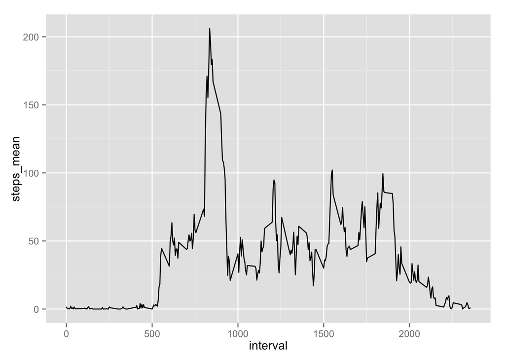

```r
g <- ggplot(entity_agg_intrvl_df, aes(x=interval, y=steps_mean))
g + geom_line()
```

#### Which 5-minute interval, on average across all the days in the dataset, contains the maximum number of steps?

```r
entity_agg_intrvl_df[which(entity_agg_intrvl_df["steps_mean"] ==
                     max(entity_agg_intrvl_df$steps_mean)), ]
```

```
##     interval steps_mean
## 104      835      206.2
```

## Imputing missing values

#### Calculate and report the total number of missing values in the dataset (i.e. the total number of rows with NAs)

```r
summary(entity_df$steps)
```

```
##    Min. 1st Qu.  Median    Mean 3rd Qu.    Max.    NA's
##     0.0     0.0     0.0    37.4    12.0   806.0    2304
```

#### Devise a strategy for filling in all of the missing values in the dataset.

Use the mean for that 5-minute interval.

#### Create a new dataset that is equal to the original dataset but with the missing data filled in.

```r
require(plyr)
intersect(names(entity_df), names(entity_agg_intrvl_df))
```

```
## [1] "interval"
```

```r
entimptd_df <- join(entity_df, entity_agg_intrvl_df, by="interval")
entimptd_df <- mutate(entimptd_df, steps_imputed=ifelse(is.na(steps), steps_mean,
                                                                      steps))
```

#### Make a histogram of the total number of steps taken each day

```
## stat_bin: binwidth defaulted to range/30. Use 'binwidth = x' to adjust this.
```

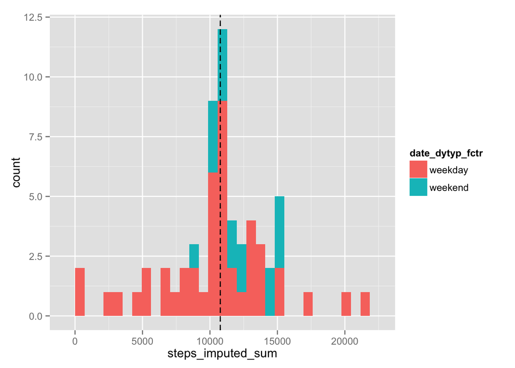

```r
entimptd_agg_date_df <- myaggregate_numorlgcl(subset(entimptd_df,
                                                     select=-c(interval, steps,
                                                               steps_mean)),
                                              "date", sum)
entimptd_agg_date_df <- mycreate_date2daytype(entimptd_agg_date_df, "date")
myplot_histogram(entimptd_agg_date_df, "steps_imputed_sum",
                 fill_col_name="date_dytyp")
```

#### Calculate and report the mean and median total number of steps taken per day. Do these values differ from the estimates from the first part of the assignment? What is the impact of imputing missing data on the estimates of the total daily number of steps?

```r
summary(entimptd_agg_date_df$steps_imputed_sum)
```

```
##    Min. 1st Qu.  Median    Mean 3rd Qu.    Max.
##      41    9820   10800   10800   12800   21200
```

```r
summary(entity_agg_date_df$steps_sum)
```

```
##    Min. 1st Qu.  Median    Mean 3rd Qu.    Max.
##      41    8840   10800   10800   13300   21200
```

The imputation does not impact the mean or median

## Are there differences in activity patterns between weekdays and weekends?

#### Create a new factor variable in the dataset with two levels – “weekday” and “weekend” indicating whether a given date is a weekday or weekend day.

```r
entimptd_df <- mycreate_date2daytype(entimptd_df, "date")
```

#### Make a panel plot containing a time series plot of the 5-minute interval (x-axis) and the average number of steps taken, averaged across all weekday days or weekend days (y-axis).

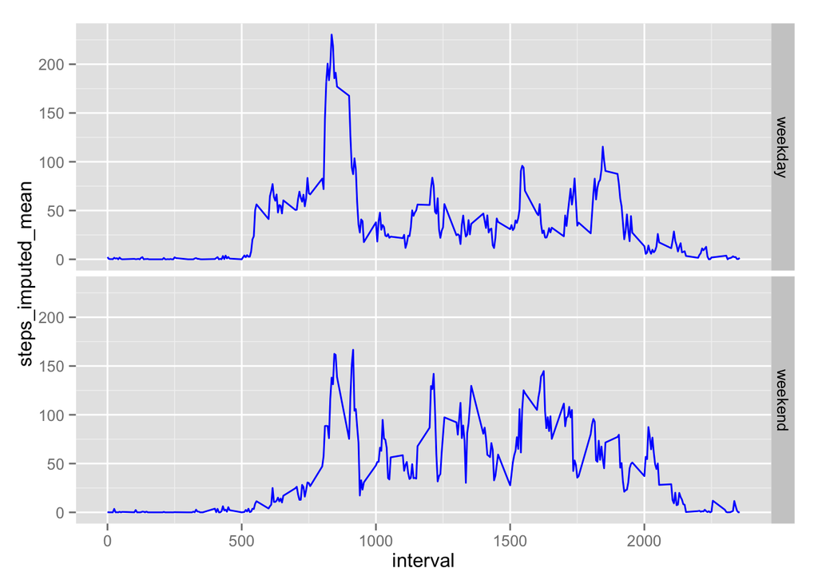

```r
entimptd_agg_intrvl_dtyp_df <- myaggregate_numorlgcl(
    subset(entimptd_df, select=-c(steps, steps_mean)),
    c("interval", "date_dytyp"), mean)
g <- ggplot(entimptd_agg_intrvl_dtyp_df, aes(x=interval, y=steps_imputed_mean))
g + geom_line(color="blue") + facet_grid(date_dytyp ~ .)
```